# Small World Phenomenon in SCUT

# Load files, libraries and functions

```r
# Load the trimmed data
Data = read.csv("DATA_trimmed.csv")

# Load the links and nodes files to construct the graph
links = read.csv("Links.csv")
nodes = read.csv("Nodes.csv")

library(igraph)
library(RColorBrewer)
library(randomcoloR)

# Load a function used for inference
load(url("http://www.stat.duke.edu/~cr173/Sta102_Sp16/Lab/inference.RData"))
# Create a function take letters out from a string
letter_num_spilt = function(str){
  str_splitted = strsplit(str,"")
  letter_length = suppressWarnings(length(str_splitted[[1]][as.numeric(str_splitted[[1]][])>10]))
  return(substr(str,1,letter_length))
}
```

# Statistical Analysis

## Examine the distribution of SCUTers’ social radii

Describe the distribution of students’ average degree of separation in SCUT. Use some plots to evaluate whether it follows a nearly normal distribution. Provide some evidence to your conclusions. (hint: use histogram, boxplot and normal probability plot.)

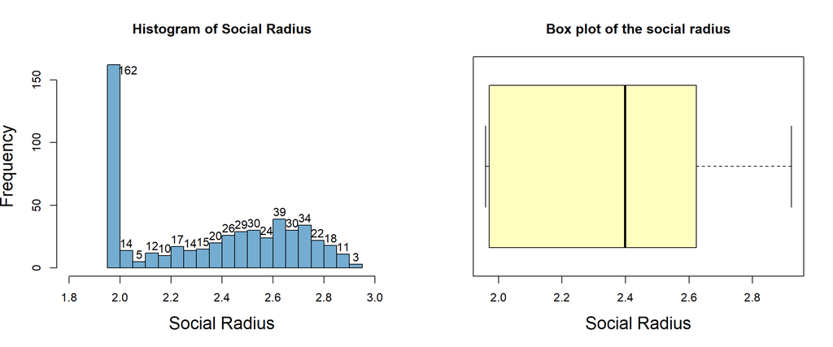

```r
par(mfrow = c(1,2))

# Plot the histogram of social radius
hist = hist(Data$Social.Radius, xlim = c(1.8,3), breaks = 15, col = "#74ADD1",
            xlab = "Social Radius", ylab = "Frequency", cex.lab = 1.5,
            main = "Histogram of Social Radius")
for (i in 1:length(hist$counts)){
  if (i == 1){
    text(hist$breaks[i]+0.080,hist$counts[i]-4,hist$counts[i],col = "black")
  }else{
    text(hist$breaks[i]+0.025,hist$counts[i]+6,hist$counts[i],col = "black")
  }
}

# Plot the box plot of social radius
box = boxplot(Data$Social.Radius, horizontal = T, varwidth = T,
        xlab = "Social Radius", cex.lab = 1.5, col = "#FFFFBF",
        main = "Box plot of the social radius")
```

```r
# Five-number summary of social radius
summary(Data$Social.Radius)
```

```
##    Min. 1st Qu.  Median    Mean 3rd Qu.    Max.
##   1.959   1.971   2.399   2.349   2.624   2.923
```

From the box plot we can see that the minimum and Q1 are quite close.

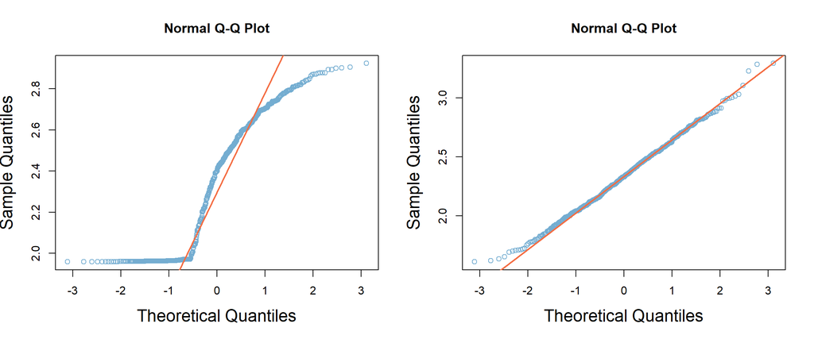

```r
par(mfrow = c(1,2))
# normal probability plot
qqnorm(Data$Social.Radius, col = "#74ADD1", cex.lab = 1.5)
qqline(Data$Social.Radius, col = "#F46D43", lwd = 2)
# comparison with a normal one
sim_norm = rnorm(n = length(Data$Social.Radius), mean = mean(Data$Social.Radius), sd = sd(Data$Social.Radius))
qqnorm(sim_norm, col = "#74ADD1",cex.lab = 1.5 )
qqline(sim_norm, col = "#F46D43", lwd = 2)
```

The points are quite departure from the line.

From what we see above, we can draw a conclusion that the distribution of the students’ average degree of separation in SCUT is not normal.

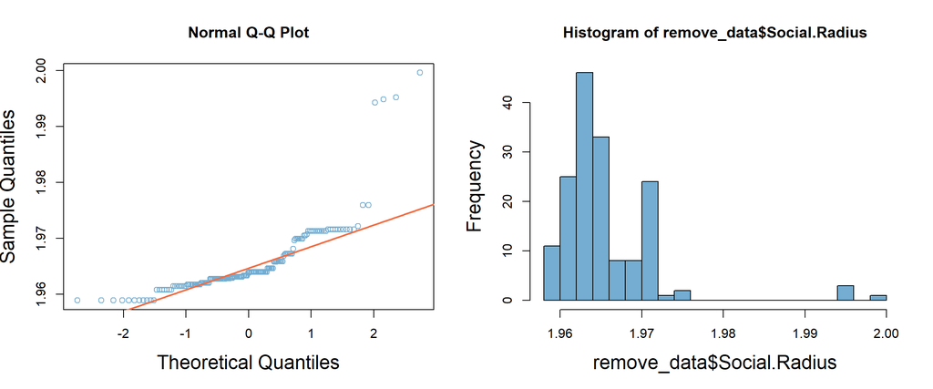

```r
par(mfrow = c(1,2))

remove_data=subset(Data, Data$Social.Radius <= 2)
qqnorm(remove_data$Social.Radius, col = "#74ADD1",cex.lab = 1.5)
qqline(remove_data$Social.Radius, col = "#F46D43", lwd = 2 )
hist(remove_data$Social.Radius,breaks = 15, col = "#74ADD1",cex.lab = 1.5)
```

## Compute 95% confidence intervals of the average degree of separation among SCUTers

Inference about the distribution of students’ average degree of separation in SCUT.(average degree of separation:the average number of social connections between any two of SCUTers)

```r
# Compute the mean shortest distances among the graph
net <- graph_from_data_frame(d=links, vertices=nodes, directed=F)
# Next line runs around half a minute
dist = distances(net) # the shortest-distance matrix of all nodes in the graph

# Compute the mean and standard deviation of the average degree of separation
sample_mean = mean(dist[,])
sample_std = sd(dist[,])
sample_amount = length(nodes)

# Compute the 95% confidence interval of the average degree of separation
upper_bound = sample_mean + 1.96*sample_std/sqrt(sample_amount)
lower_bound = sample_mean - 1.96*sample_std/sqrt(sample_amount)

# Show the result
cat("The 95% confidence interval of the average degree of separation among SCUTers is:", "[",lower_bound,",",upper_bound,"]")
```

```
## The 95% confidence interval of the average degree of separation among SCUTers is: [ 1.925744 , 3.717624 ]
```

## What’s the composition or division of each attribute in the dataset? (hint: use table(x) and barplot(x))

### Decomposition according to campus and grade

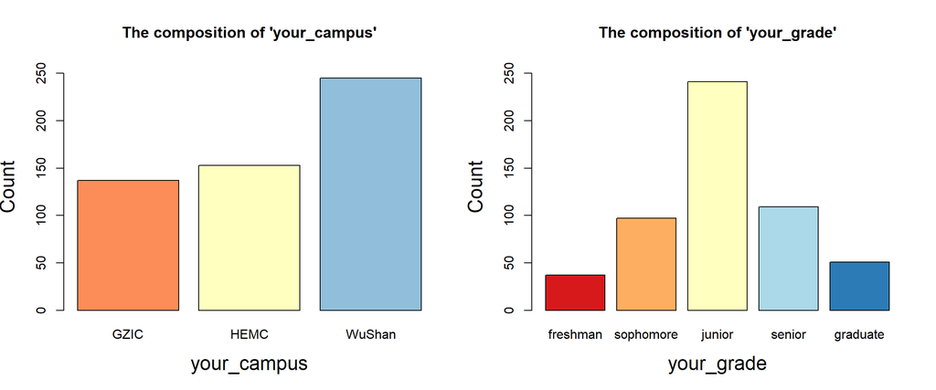

```r
par(mfrow = c(1,2))

barplot(table(Data$your_campus), col=brewer.pal(n = 3, name = "RdYlBu"), border = c('black'), ylim = c(0, 260), main = "The composition of 'your_campus'", xlab = "your_campus", ylab = 'Count',cex.lab = 1.5)
barplot(table(Data$your_grade)[c(1,5,3,4,2)], col=brewer.pal(n = 5, name = "RdYlBu"), border = c('black'), ylim = c(0, 260), main = "The composition of 'your_grade'", xlab = "your_grade", ylab = 'Count',cex.lab = 1.5)
```

### Decomposition according to academy

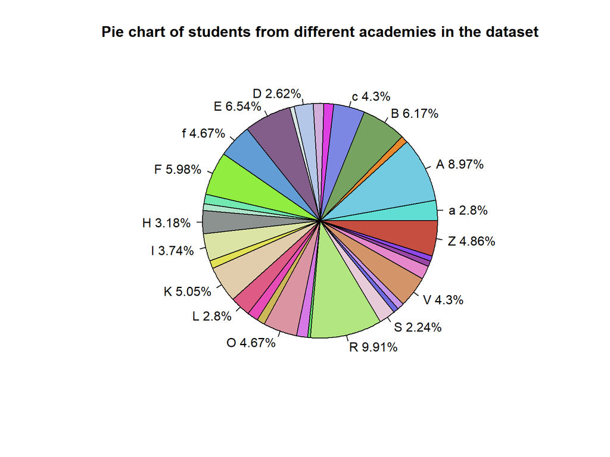

```r
# Remove the index-number of each interviewed student
Data_no_index = letter_num_spilt(as.character(Data$your_acade))

# Create a vector constitutes of all academies
acade = c("A","B","C","D","E","F","G","H","I","J","K","L","M","N","O","P","Q","R","S","T","U","V","W","X","Y","Z","a","b","c","d","e","f","g")

# Plot the pie chart
labs = rep(0,length(table(Data_no_index)))
for (i in 1:length(table(Data_no_index))){
  if ((100*table(Data_no_index)/535)[i] >= 2){
    temp = paste(names(table(Data_no_index))[i],round((100*table(Data_no_index)/535)[i],2),sep = " ")
    labs[i] = paste(temp,"%",sep = "")
  }else{
    labs[i] = ""
  }
}
pie(table(Data_no_index), col=distinctColorPalette(33),edges = 800,label = labs,
    main = "Pie chart of students from different academies in the dataset")
```

### Decomposition according to other attributes

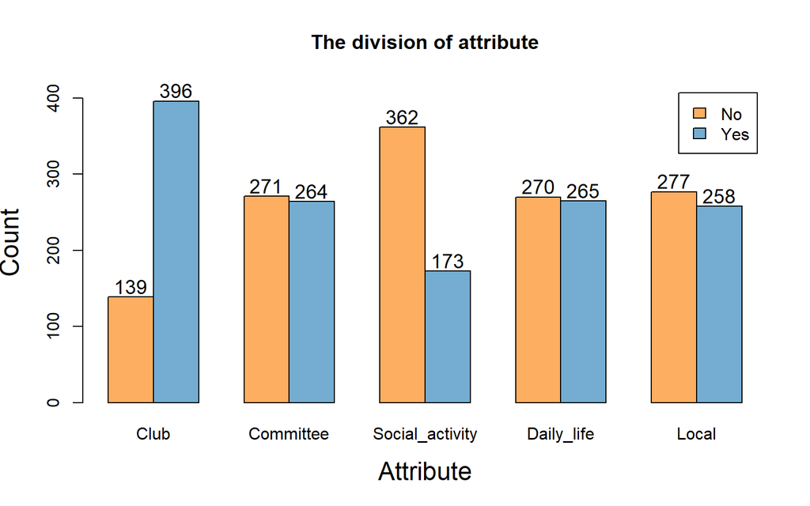

```r
sep_club_stud_org <- table(Data$club_stud_org)
sep_class_commi <- table(Data$class_commi)
sep_soci_acti <- table(Data$soci_acti)
sep_dali_live <- table(Data$dali_live)
sep_local <- table(Data$local)

a <- as.data.frame.array(sep_club_stud_org)
b <- as.data.frame.array(sep_class_commi)
c <- as.data.frame.array(sep_soci_acti)
d <- as.data.frame.array(sep_dali_live)
e <- as.data.frame.array(sep_local)
k <- cbind(a,b,c,d,e)
row.names(k) = c("No","Yes")


bar = barplot(height = matrix(c(k[1,1],k[2,1],k[1,2],k[2,2],k[1,3],k[2,3],k[1,4],k[2,4],k[1,5],k[2,5]),
                        ncol = 5, nrow = 2),
        names.arg = c('Club', 'Committee', 'Social_activity','Daily_life','Local'),
        col = c('#FDAE61', '#74ADD1'),
        border = c('black'),
        main = "The division of attribute",
        xlab = 'Attribute',
        ylab = 'Count', cex.lab = 1.5,
        horiz = FALSE,
        ylim = c(0, 420),
        legend.text = c('No', 'Yes'),
        beside = TRUE
       )
for (i in 1:dim(bar)[1]){
  for (j in 1:dim(bar)[2]) {
    text(bar[i,j],k[i,j] + 14,k[i,j],cex = 1.2)
  }
}
```

## Inference about the influence of some subjective influencing factors to the students’ average degree of separation

### The average degree of separation & school

Test if the average degree of separation between students majoring in natural science and in other like humanities and social sciences are different. (hint: use inference())

```r
# Distinguish school
science_school = c("A","B","C","D","E","F","G","H","I","J","K","L","M","N","O","P","Q","V","W","X","Y","g")
art_school = c("R","S","T","U","Z","a","b","c","d","e","f")

# Create a vector to store the science/art information
school = rep(0,length(Data$your_acade))
# Distinguish science or art school according to the academy
school[letter_num_spilt(as.character(Data$your_acade)) %in% science_school] = "Science"
school[letter_num_spilt(as.character(Data$your_acade)) %in% art_school] = "Others"

# Append the school vector to the trimmed data
Data[,10] = school
names(Data)[10] = "school"

# Change the label name
Social_Radius = Data$Social.Radius
School = Data$school

# Inference test
suppressWarnings (inference(y = Social_Radius, x = School, est = "mean", type = "ht", null = 0, alternative = "twosided", method = "theoretical"))
```

```
## Response variable: numerical, Explanatory variable: categorical
## Difference between two means
## Summary statistics:
## n_Others = 179, mean_Others = 2.3478, sd_Others = 0.3044
## n_Science = 356, mean_Science = 2.3495, sd_Science = 0.3204
```

```
## Observed difference between means (Others-Science) = -0.0017
## H0: mu_Others - mu_Science = 0
## HA: mu_Others - mu_Science != 0
## Standard error = 0.028
## Test statistic: Z =  -0.06
## p-value =  0.9522
```

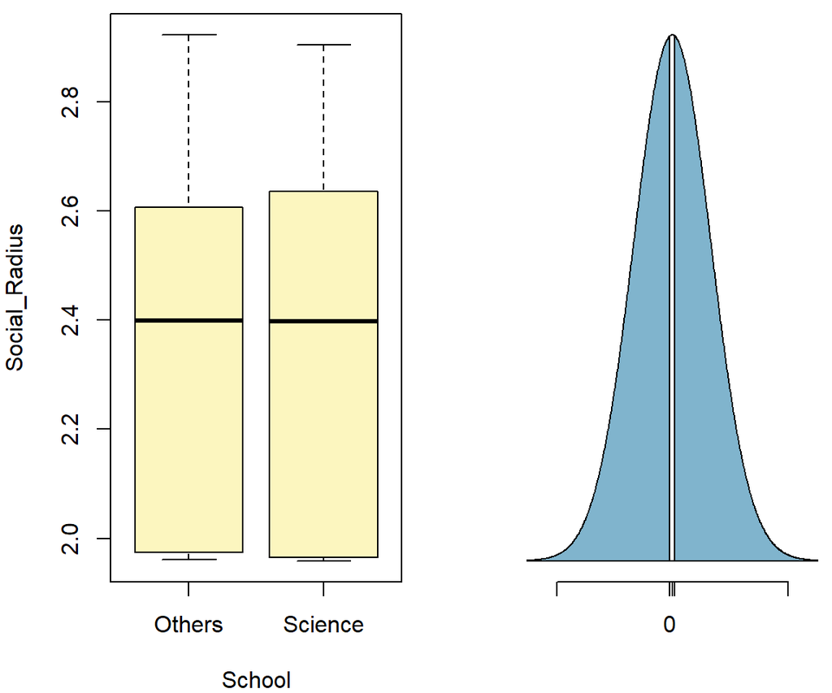

From the result in the above chunk, the p-value is quite large, which means we fail to reject H0, so there is no difference in the average degree of separation between students majoring in natural science and in other like humanities and social sciences.

### The average degree of separation & academy

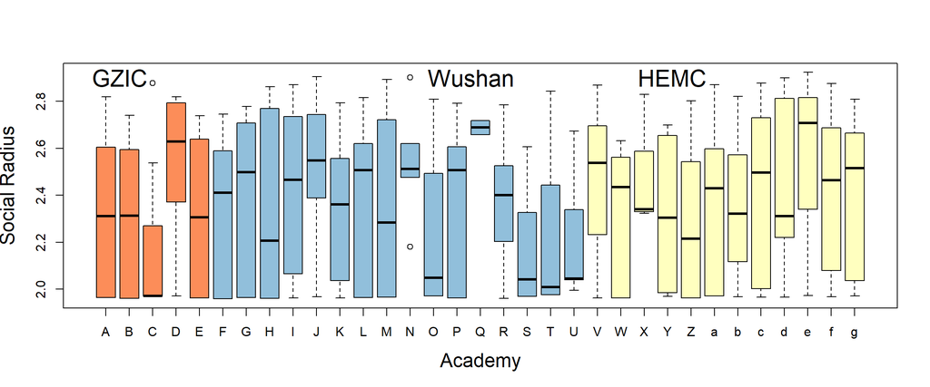

```r
# Remove the index-number of each interviewed student
Data_no_index = letter_num_spilt(as.character(Data$your_acade))
#
Campus_gzic = unique(Data_no_index[Data$your_campus == "GZIC"])
Campus_wushan = unique(Data_no_index[Data$your_campus == "WuShan"])
Campus_hemc = unique(Data_no_index[Data$your_campus == "HEMC"])

# Create a vector constitutes of all academies
acade = c("A","B","C","D","E","F","G","H","I","J","K","L","M","N","O","P","Q","R","S","T","U","V","W","X","Y","Z","a","b","c","d","e","f","g")

# Create vectors to store social radii for each academy
bp = boxplot(Data$Social.Radius ~ factor(Data_no_index,acade),
        xlab = "Academy", ylab = "Social Radius", cex.lab = 1.5, plot = FALSE)
color = rep(0,length(bp$names))
color[bp$names %in% Campus_gzic] = "#FC8D59"
color[bp$names %in% Campus_wushan] = "#91BFDB"
color[bp$names %in% Campus_hemc] = "#FFFFBF"
bp = boxplot(Data$Social.Radius ~ factor(Data_no_index,acade),
            xlab = "Academy", ylab = "Social Radius", cex.lab = 1.5,
            col = color)
text(1.6,2.9,"GZIC",col = "black", cex = 1.8)
text(16.6,2.9,"Wushan",col = "black", cex = 1.8)
text(25.2,2.9,"HEMC",col = "black", cex = 1.8)
```

### The average degree of separation & campus

Make a mosaic plot about “social radius” and “campus”, and what can we learn about from it. (hint: use mosaicplot(table(x,y)))

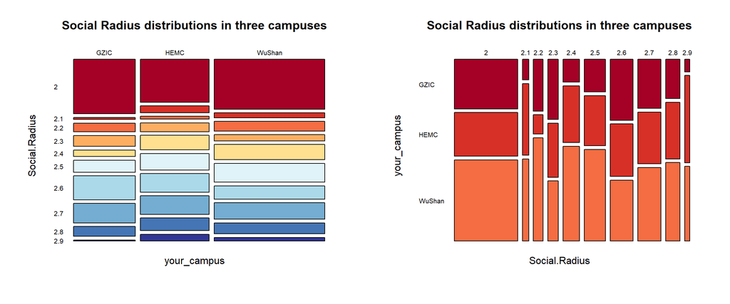

```r
par(mfrow = c(1,2))

your_campus <- Data$your_campus
Social.Radius <- round(Data$Social.Radius,digits=1)
mosaicplot(table(your_campus,Social.Radius), main = "Social Radius distributions in three campuses", col=brewer.pal(n = 10, name = "RdYlBu"), border = c('black'),las = 1)
mosaicplot(table(Social.Radius,your_campus), main = "Social Radius distributions in three campuses", col=brewer.pal(n = 10, name = "RdYlBu"), border = c('black'),las = 1)
```

### The average degree of separation & local/non-local

Some suggest that it is easier for local students to build a wider social circle at school than non-local students, conduct a test of significance to see if we have enough evidence to say it.

```r
suppressWarnings(inference(y = Data$Social.Radius, x = Data$local, est = "mean", type = "ht", null = 0, alternative = "greater", method = "theoretical"))
```

```
## Response variable: numerical, Explanatory variable: categorical
## Difference between two means
## Summary statistics:
## n_0 = 277, mean_0 = 2.3543, sd_0 = 0.3274
## n_1 = 258, mean_1 = 2.3432, sd_1 = 0.3013
```

```
## Observed difference between means (0-1) = 0.011
## H0: mu_0 - mu_1 = 0
## HA: mu_0 - mu_1 > 0
## Standard error = 0.027
## Test statistic: Z =  0.406
## p-value =  0.3424
```

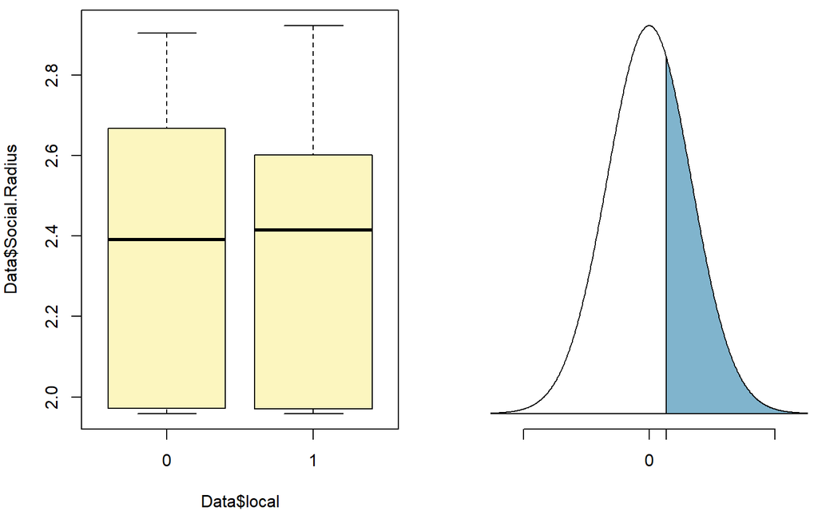

### The average degree of separation & grade

Use box plot to show how the length of time in school relates to the average degree of separation? (hint: use boxplot(x~y))

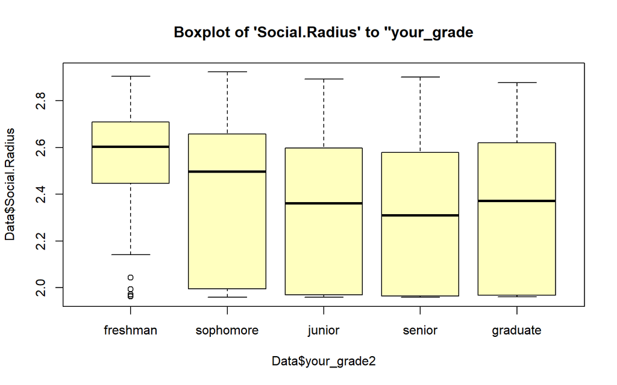

```r
Data$your_grade2 <- factor(Data$your_grade,levels = c("freshman", "sophomore", "junior", "senior", "graduate"))
boxplot(Data$Social.Radius~Data$your_grade2, main = "Boxplot of 'Social.Radius' to ''your_grade", col = "#FFFFBF")
```

Form the box plot we can see that as the length of time in school increase the main body of the social radius move downwards, which means it is easier for them to find an arbitrary student in SCUT. You might have noticed that there is a rise in graduate, this is because some graduates are new to his school.

## Inferences about the influences of some objective influencing factors to the students’ average degree of separation

### The average degree of separation & join a club/student organization or not

Conduct a hypothesis test at the α = 0.1 significance level evaluating whether joining a club or student organization helps expand our social circle? Interpret the p-value.

```r
Social_Radius=Data$Social.Radius
Club_stud_org=Data$club_stud_org
Club_stud_org[Club_stud_org==0]<-"didn't join"
Club_stud_org[Club_stud_org==1]<-"joined"
inference(y =Social_Radius, x =Club_stud_org, est = "mean", type = "ht", null = 0, alternative = "greater", method = "theoretical",order = c("didn't join","joined"))
```

```
## Response variable: numerical, Explanatory variable: categorical
## Difference between two means
## Summary statistics:
## n_didn't join = 139, mean_didn't join = 2.4292, sd_didn't join = 0.3428
## n_joined = 396, mean_joined = 2.3208, sd_joined = 0.2998
```

```
## Observed difference between means (didn't join-joined) = 0.1084
## H0: mu_didn't join - mu_joined = 0
## HA: mu_didn't join - mu_joined > 0
## Standard error = 0.033
## Test statistic: Z =  3.311
## p-value =  5e-04
```

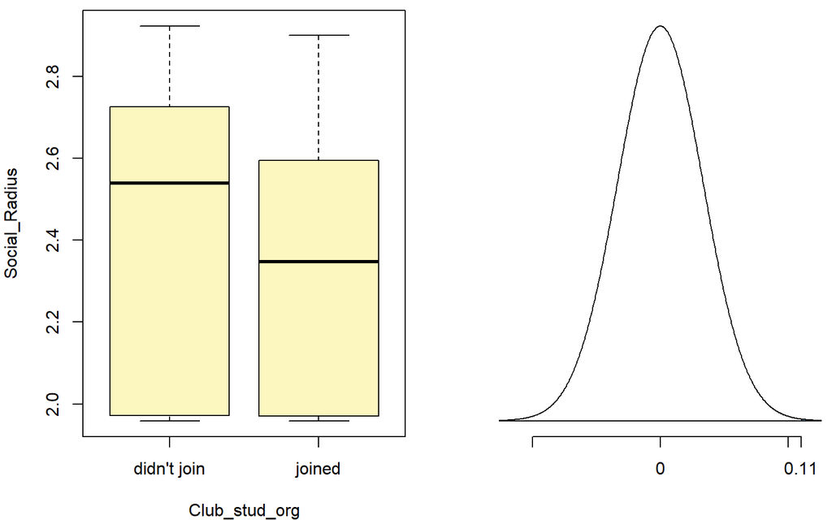

The result shows that the social radius of them who joined a club or student organization is smaller than who did not.

### The average degree of separation & join the class committee or not

Compute both the 95% confidence of intervals of the mean “Social_Radius” of the students who have joined or not joined the class committee, and compare the difference.

```r
Class_committee_joined<-Data$Social.Radius[Data$class_commi==1]
Class_committee_not_joined<-Data$Social.Radius[Data$class_commi==0]
print("students who have joined class committee:")
```

```
## [1] "students who have joined class committee:"
```

```r
inference(y =Class_committee_joined, est = "mean", type = "ci", null = 0, alternative = "twosided", method = "theoretical",conflevel = 0.95)
```

```
## Single mean
## Summary statistics:
```

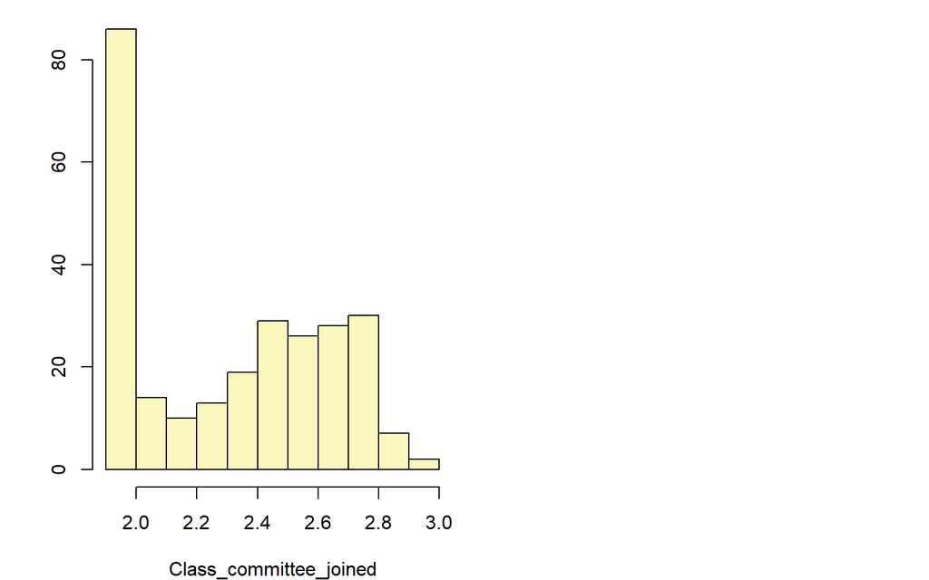

```
## mean = 2.3198 ;  sd = 0.3109 ;  n = 264
## Standard error = 0.0191
## 95 % Confidence interval = ( 2.2823 , 2.3573 )
```

```r
print("students who have not joined class committee:")
```

```
## [1] "students who have not joined class committee:"
```

```r
inference(y =Class_committee_not_joined, est = "mean", type = "ci", null = 0, alternative = "twosided", method = "theoretical",conflevel = 0.95)
```

```
## Single mean
## Summary statistics:
```

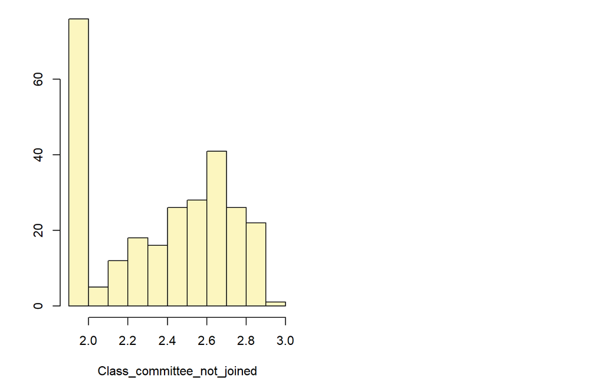

```
## mean = 2.3773 ;  sd = 0.3166 ;  n = 271
## Standard error = 0.0192
## 95 % Confidence interval = ( 2.3396 , 2.415 )
```

### The average degree of separation & attend social activities frequently or not

Use “soci_acti” and “social_Radius” summarize them and comment on any apparent relationship you see.

```r
Social_Radius=Data$Social.Radius
Social_activity=Data$soci_acti
Social_activity[Social_activity==1]="Social active"
Social_activity[Social_activity==0]="Social inactive"
inference(y =Social_Radius, x =Social_activity, est = "mean", type = "ht", null = 0, alternative = "greater", method = "theoretical",order = c("Social inactive","Social active"))
```

```
## Response variable: numerical, Explanatory variable: categorical
## Difference between two means
## Summary statistics:
## n_Social inactive = 362, mean_Social inactive = 2.392, sd_Social inactive = 0.3211
## n_Social active = 173, mean_Social active = 2.2589, sd_Social active = 0.2815
```

```
## Observed difference between means (Social inactive-Social active) = 0.1331
## H0: mu_Social inactive - mu_Social active = 0
## HA: mu_Social inactive - mu_Social active > 0
## Standard error = 0.027
## Test statistic: Z =  4.884
## p-value =  0
```

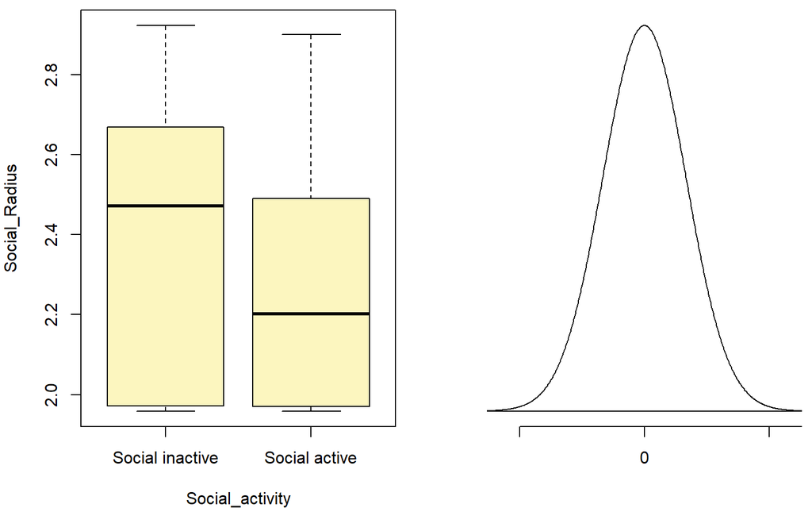

P_value =0 (means P_value is very small). Reject $H_{0}$ and accept $H_{a}$. From the data, clearly know that the social activity is definitely affect the social. The social active students have less social distance.

### The average degree of separation & colorful campus life or not

Use “dali_live” to separate the population, then describe and compare the distributions of their “social radius”.

```r
Daily_live_rich<-Data$Social.Radius[Data$dali_live==1]
Daily_live_monotonous<-Data$Social.Radius[Data$dali_live==0]
par(mfrow=c(1,2))
print("The summary of rich daily live:")
```

```
## [1] "The summary of rich daily live:"
```

```r
summary(Daily_live_rich)
```

```
##    Min. 1st Qu.  Median    Mean 3rd Qu.    Max.
##   1.959   1.970   2.263   2.286   2.547   2.904
```

```r
print("The summary of rich monotonous live:")
```

```
## [1] "The summary of rich monotonous live:"
```

```r
summary(Daily_live_monotonous)
```

```
##    Min. 1st Qu.  Median    Mean 3rd Qu.    Max.
##   1.959   1.971   2.496   2.410   2.696   2.923
```

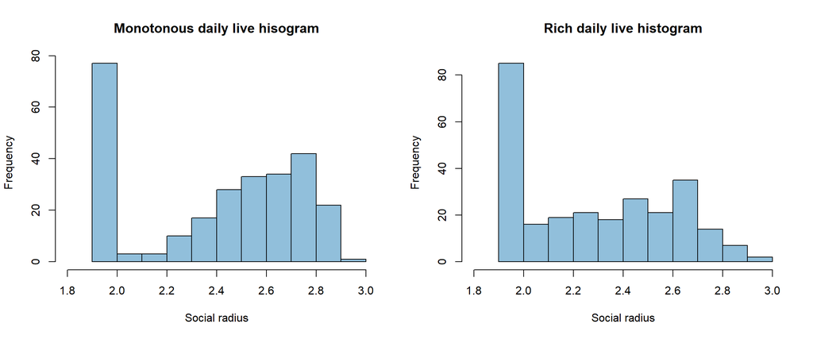

```r
hist(Daily_live_monotonous,xlim = c(1.8,3), col = "#91BFDB",
     main = "Monotonous daily live hisogram",xlab = "Social radius")
hist(Daily_live_rich,xlim = c(1.8,3), col = "#91BFDB",
     main = "Rich daily live histogram",xlab = "Social radius")
```

The minimum and maximum number of monotonous daily live students and rich daily live students are almost the same. The mean value, median and 3rd quarter value of rich daily lift students are smaller than students who have monotonous life. The number of social radius less than 2.0 is almost same and large. For the data which social radius larger than 2.0, The distribution of monotonous daily life students’ social radius is unimodal whose center is within 2.7 to 2.8 and left-skewed. Also for the data selected above, the distribution of rich daily life students’ social radius is unimdal whose center is within 2.6 to 2.7. The data change of monotonous daily life students sharper than rich daily life.